# Proyecto Final

Adrian Figueroa Rodriguez

23 de noviembre de 2018

# Pregunta 1

## Do you contribute to open source projects?

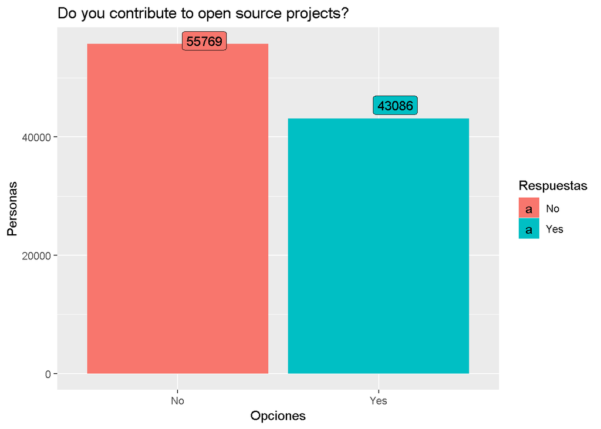

```r
ggplot(osData <- data.frame(table(data$OpenSource)), aes(osData$Var1, osData$Freq, fill = osData$Var1)) +
  geom_bar(stat = "identity") +
  ggrepel::geom_label_repel(aes(label = Freq), data = osData)+
  labs(x = "Opciones", y = "Personas", title = "Do you contribute to open source projects?", fill = "Respuestas")
```

### Se nota que mas de la mitad de las personas que usan stackoverflow no aportan o participan en proyectos de open source

# Pregunta 2

## In which country do you currently reside?

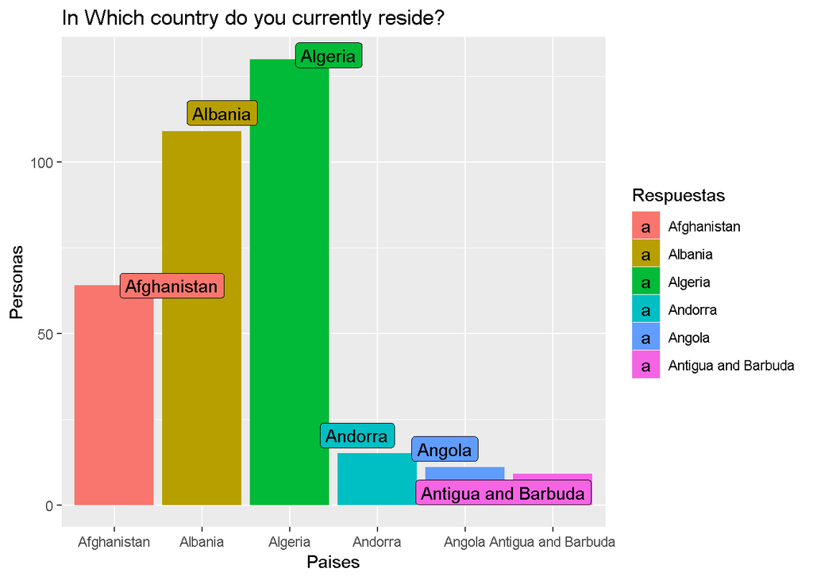

```r
#pregunta 2
ggplot(cData <- head(data.frame(table(data$Country))), aes(cData$Var1, cData$Freq, fill = cData$Var1)) +
  geom_bar(stat = "identity") +
  ggrepel::geom_label_repel(aes(label = Var1), data = cData)+
  labs(x = "Paises", y = "Personas", title = "In Which country do you currently reside?", fill = "Respuestas")
```

### Por los datos que se muestran se puede notar que en Algeria tienen mas desarrolladores que algun otro lado de los primeros 6.

# Pregunta 3

## Are you currently enrolled in a formal, degree-granting college or university program?

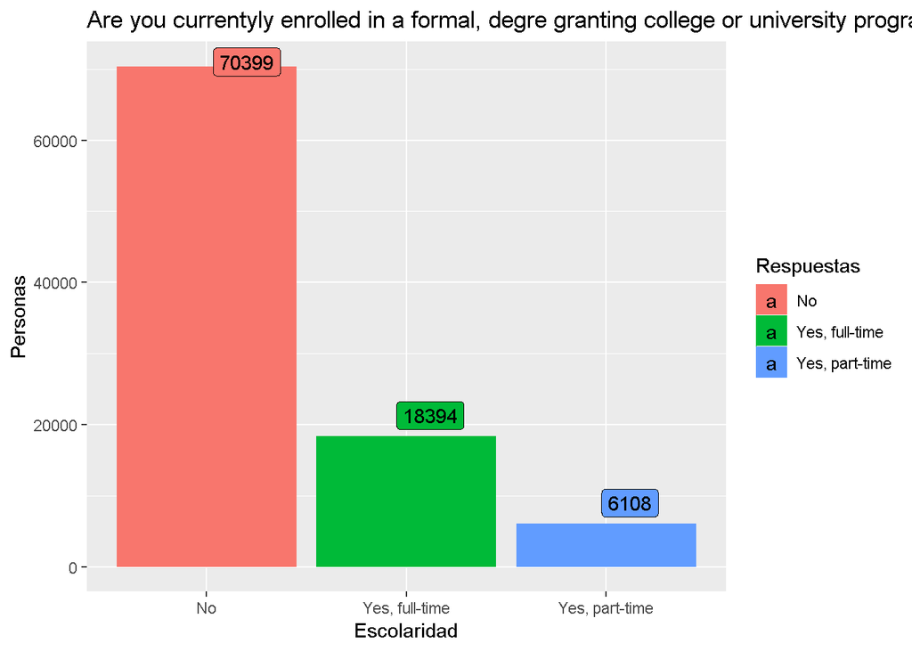

```r
ggplot(cstudent <- data.frame(table(data$Student)), aes(cstudent$Var1, cstudent$Freq, fill = cstudent$Var1)) +
  geom_bar(stat = "identity") +
  ggrepel::geom_label_repel(aes(label = cstudent$Freq), data = cstudent)+
  labs(x = "Escolaridad", y = "Personas",  title = "Are you currentyly enrolled in a formal, degre granting college or university program?", fill = "Respuestas")
```

# Pregunta 4

## Which of the following best describes your current employment status?

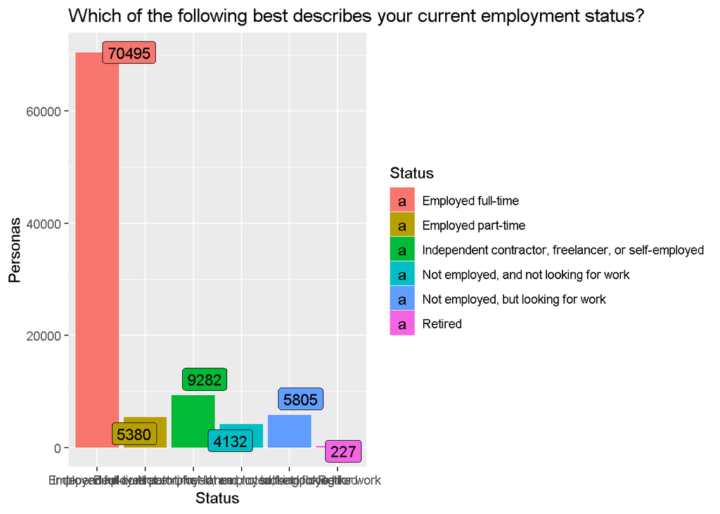

```r
ggplot(dfemploy <- data.frame(table(data$Employment)), aes(dfemploy$Var1 , dfemploy$Freq , fill = dfemploy$Var1))+
  geom_bar(stat = "identity") +
  ggrepel::geom_label_repel(aes(label = dfemploy$Freq), data = dfemploy)+
  labs(x = "Status", y = "Personas", title.size = .5,title = "Which of the following best describes your current employment status?", colour = "Estado", fill = "Status")
```

### La mayor parte de los usuarios de stackoverflow tienen un trabajo de tiempo completo y muy pocos o no tienen o estan retirados ya.

# Pregunta 5

## Which of the following best describes the highest level of formal education that you’ve completed?

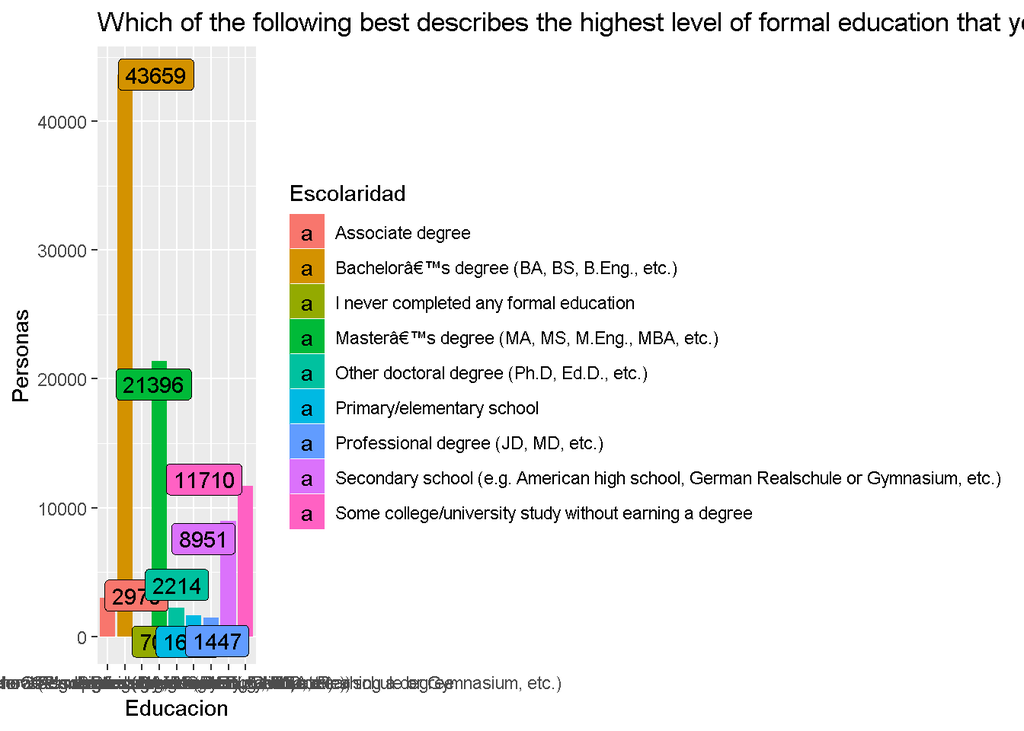

```r
ggplot(dfeducation <- data.frame(table(data$FormalEducation)), aes(dfeducation$Var1, dfeducation$Freq, fill = dfeducation$Var1))+
  geom_bar(stat = "identity") +
  ggrepel::geom_label_repel(aes(label = dfeducation$Freq), data = dfeducation)+
  labs(x = "Educacion", y = "Personas", title.size = .5,title = "Which of the following best describes the highest level of formal education that you've completed?", colour = "Grado", fill = "Escolaridad")
```

### La mayor parte de las personas que si tienen un estudio en stackoverflow tiene un bachelor’s degree y Masters degree, hay muy pocos que no tienen ninguna esocolaridad formal o han alcanzado un Professional degree

# Pregunta 6

## How many observations per year?

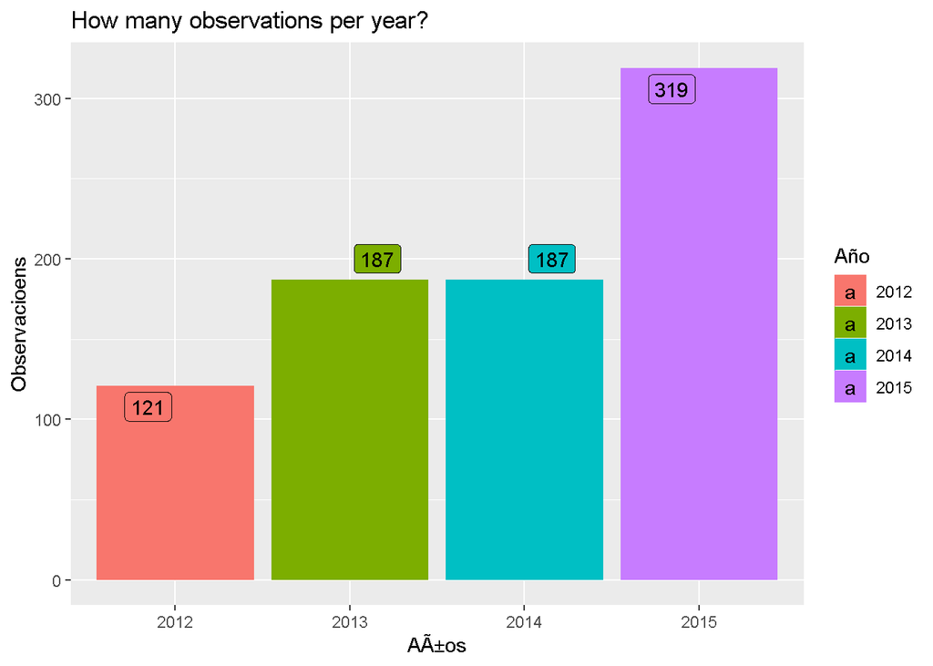

```r
ggplot(dfopy <- data.frame(table(data2$year)), aes(dfopy$Var1, dfopy$Freq, fill = dfopy$Var1))+
  geom_bar(stat = "identity") +
  ggrepel::geom_label_repel(aes(label = dfopy$Freq), data = dfopy)+
  labs(x = "AÃ±os", y = "Observacioens", title.size = .5,title = "How many observations per year?", colour = "AÃ±o", fill = "Año")
```

# Pregunta 7

## In which year and season the collection data process began?

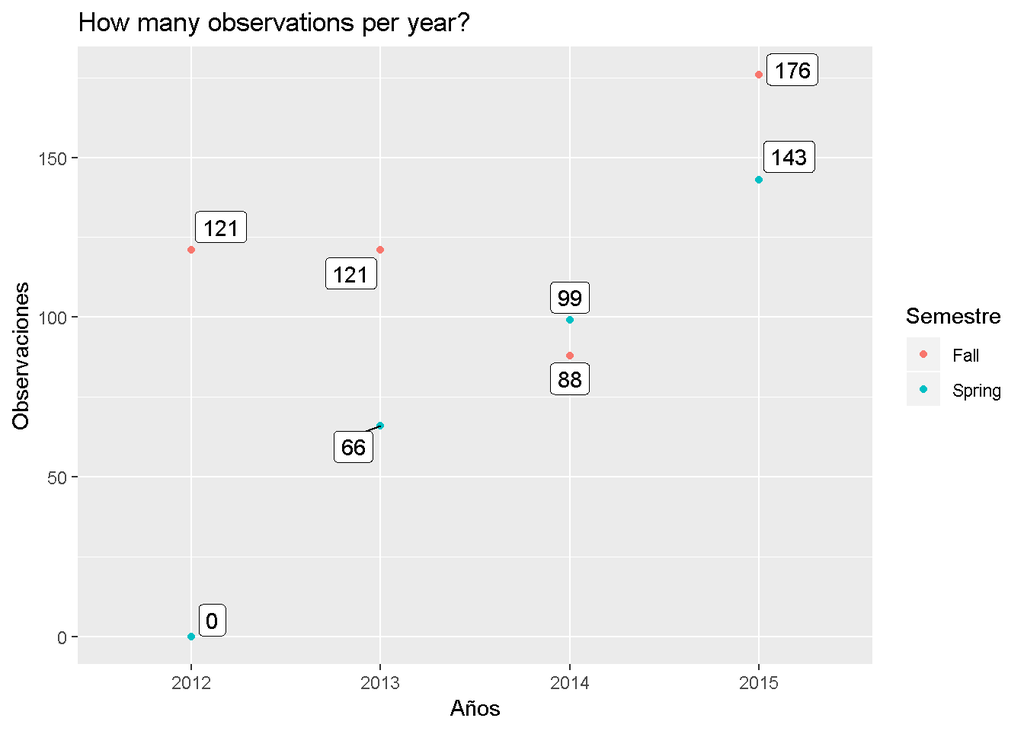

```r
ggplot(t1ysdc <- as.data.frame(table(data2$year, data2$semester)), aes(Var1,Freq))+
  geom_point(aes(color = Var2))+
  ggrepel::geom_label_repel(aes(label = Freq), data = t1ysdc)+
  labs(x = "Años", y = "Observaciones", title.size = .5,title = "How many observations per year?", colour = "Semestre")
```

### Se puede notar que la cantidad de observacioens en primavera van aumentando con año y las de otoño se mantienen 2 años, cae y luego mejora.